# MA8701 Advanced methods in statistical inference and learning

Study technique

Mette Langaas IMF/NTNU

19 January, 2021

# Organize thoughts and create neural hooks

(From “A mind for numbers”)

Before you start to really read and write down and work with the equations and concepts “Prime your mental pump” by a picture walk through the chapter you will study, looking only at the graphics (pictures/graphs) and at the section headings, summaries and questions in the end of each chapter. This will help you organize your thoughts and create “neural hooks” to hang your thinking on.

# Concept maps

(beautifully presented in How Learning Works, reference below)

A concept map is drawn as a network structure and depicts suggested relationships between concepts, and is used by designers, engineers, writers, … to organize and structure knowledge.

- Can be used as a tool to help students (and teachers) structure information.
- Can be related to a topic or a larger part of the course.
- Can be drawn with prior knowledge, then with what is learned, and maybe in the end of the course after being able to connect to other course parts.

Elements of a concept map

- Nodes: The concepts
- Links: How are the concepts connected
- Description on links: relationships such as causes, requires, contributes to, sums to, …

Further reading: https://web.stanford.edu/dept/SUSE/projects/ireport/articles/concept_maps/The%20Theory%20Underlying%20Concept%20Maps.pdff

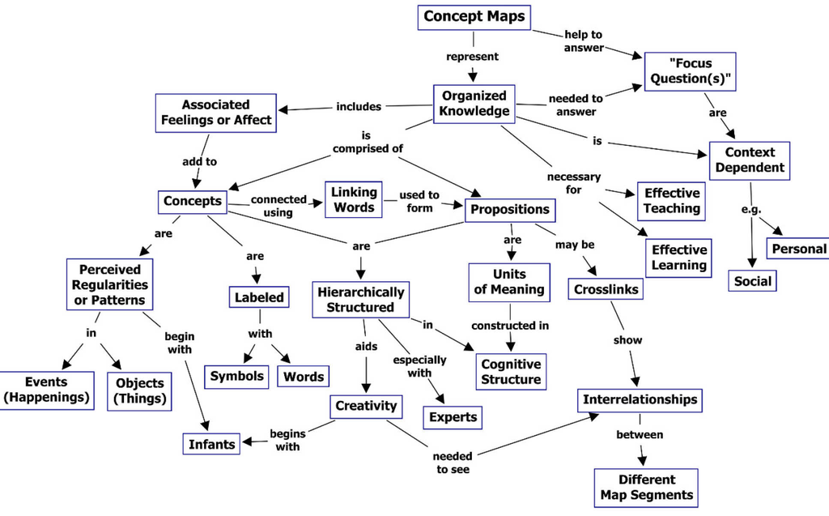

Example concept map

# References

Barbara Oakley: “A mind for numbers – how to excel at math and science even if you funked algebra”.

Susan A. Ambrose, Michael W. Bridges, Michele DiPietro, Marsha C. Lovett, and Marie K. Norman (2010): “How Learning Works: Seven Research-Based Principles for Smart Teaching”